# Risk Factor Analysis

## Outcome Variable

**Outcome Variable:** sstunted

## Predictor Variables

**Intervention Variable:** mbmi

**Adjustment Set:**

unadjusted

## Stratifying Variables

The analysis was stratified on these variable(s):

- agecat
- studyid

The following strata were considered:

- agecat: 12 months, studyid: ki0047075b-MAL-ED
- agecat: 12 months, studyid: ki1017093-NIH-Birth
- agecat: 12 months, studyid: ki1017093b-PROVIDE
- agecat: 12 months, studyid: ki1017093c-NIH-Crypto
- agecat: 12 months, studyid: ki1066203-TanzaniaChild2
- agecat: 12 months, studyid: ki1126311-ZVITAMBO
- agecat: 12 months, studyid: ki1148112-LCNI-5
- agecat: 18 months, studyid: ki0047075b-MAL-ED
- agecat: 18 months, studyid: ki1017093-NIH-Birth
- agecat: 18 months, studyid: ki1017093b-PROVIDE
- agecat: 18 months, studyid: ki1017093c-NIH-Crypto
- agecat: 18 months, studyid: ki1066203-TanzaniaChild2
- agecat: 18 months, studyid: ki1126311-ZVITAMBO
- agecat: 18 months, studyid: ki1148112-LCNI-5
- agecat: 24 months, studyid: ki0047075b-MAL-ED
- agecat: 24 months, studyid: ki1017093-NIH-Birth
- agecat: 24 months, studyid: ki1017093b-PROVIDE
- agecat: 24 months, studyid: ki1017093c-NIH-Crypto
- agecat: 24 months, studyid: ki1066203-TanzaniaChild2
- agecat: 24 months, studyid: ki1126311-ZVITAMBO
- agecat: 24 months, studyid: ki1148112-LCNI-5
- agecat: 3 months, studyid: ki0047075b-MAL-ED
- agecat: 3 months, studyid: ki1017093-NIH-Birth
- agecat: 3 months, studyid: ki1017093b-PROVIDE
- agecat: 3 months, studyid: ki1017093c-NIH-Crypto
- agecat: 3 months, studyid: ki1066203-TanzaniaChild2
- agecat: 3 months, studyid: ki1126311-ZVITAMBO
- agecat: 6 months, studyid: ki0047075b-MAL-ED
- agecat: 6 months, studyid: ki1017093-NIH-Birth
- agecat: 6 months, studyid: ki1017093b-PROVIDE
- agecat: 6 months, studyid: ki1017093c-NIH-Crypto
- agecat: 6 months, studyid: ki1066203-TanzaniaChild2
- agecat: 6 months, studyid: ki1126311-ZVITAMBO
- agecat: 6 months, studyid: ki1148112-LCNI-5
- agecat: 9 months, studyid: ki0047075b-MAL-ED
- agecat: 9 months, studyid: ki1017093-NIH-Birth
- agecat: 9 months, studyid: ki1017093b-PROVIDE
- agecat: 9 months, studyid: ki1017093c-NIH-Crypto
- agecat: 9 months, studyid: ki1066203-TanzaniaChild2
- agecat: 9 months, studyid: ki1126311-ZVITAMBO
- agecat: 9 months, studyid: ki1148112-LCNI-5
- agecat: Birth, studyid: ki0047075b-MAL-ED
- agecat: Birth, studyid: ki1017093-NIH-Birth
- agecat: Birth, studyid: ki1017093c-NIH-Crypto
- agecat: Birth, studyid: ki1126311-ZVITAMBO

### Dropped Strata

Some strata were dropped due to rare outcomes:

- agecat: Birth, studyid: ki0047075b-MAL-ED
- agecat: Birth, studyid: ki1017093-NIH-Birth
- agecat: Birth, studyid: ki1017093c-NIH-Crypto
- agecat: 3 months, studyid: ki1017093b-PROVIDE
- agecat: 3 months, studyid: ki1066203-TanzaniaChild2
- agecat: 6 months, studyid: ki1017093-NIH-Birth
- agecat: 6 months, studyid: ki1017093b-PROVIDE
- agecat: 6 months, studyid: ki1017093c-NIH-Crypto
- agecat: 6 months, studyid: ki1066203-TanzaniaChild2
- agecat: 6 months, studyid: ki1126311-ZVITAMBO
- agecat: 6 months, studyid: ki1148112-LCNI-5
- agecat: 9 months, studyid: ki1017093b-PROVIDE
- agecat: 9 months, studyid: ki1066203-TanzaniaChild2
- agecat: 9 months, studyid: ki1148112-LCNI-5
- agecat: 12 months, studyid: ki1017093b-PROVIDE
- agecat: 12 months, studyid: ki1066203-TanzaniaChild2
- agecat: 12 months, studyid: ki1148112-LCNI-5
- agecat: 18 months, studyid: ki1017093b-PROVIDE
- agecat: 18 months, studyid: ki1066203-TanzaniaChild2
- agecat: 18 months, studyid: ki1126311-ZVITAMBO
- agecat: 18 months, studyid: ki1148112-LCNI-5
- agecat: 24 months, studyid: ki1017093b-PROVIDE
- agecat: 24 months, studyid: ki1066203-TanzaniaChild2
- agecat: 24 months, studyid: ki1126311-ZVITAMBO
- agecat: 24 months, studyid: ki1148112-LCNI-5

## Methods Detail

We’re interested in the causal parameters $E[Y_a]$ for all values of $a \in \mathcal{A}$. These parameters represent the mean outcome if, possibly contrary to fact, we intervened to set all units to have $A=a$. Under the randomization and positivity assumptions, these are identified by the statistical parameters $\psi_a=E_W[E_{Y|A,W}(Y|A=a,W)]$. In addition, we’re interested in the mean of $Y$, $E[Y]$ under no intervention (the observed mean). We will estimate these parameters by using SuperLearner to fit the relevant likelihood factors – $E_{Y|A,W}(Y|A=a,W)$ and $p(A=a|W)$, and then updating our likelihood fit using a joint TMLE.

For unadjusted analyses ($W=\{\}$), initial likelihoods were estimated using Lrnr_glm to estimate the simple $E(Y|A)$ and Lrnr_mean to estimate $p(A)$. For adjusted analyses, a small library containing Lrnr_glmnet, Lrnr_xgboost, and Lrnr_mean was used.

Having estimated these parameters, we will then use the delta method to estimate relative risks and attributable risks relative to a prespecified baseline level of $A$.

# Results Detail

## Results Plots

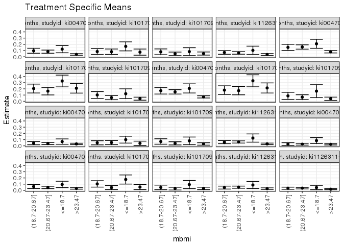

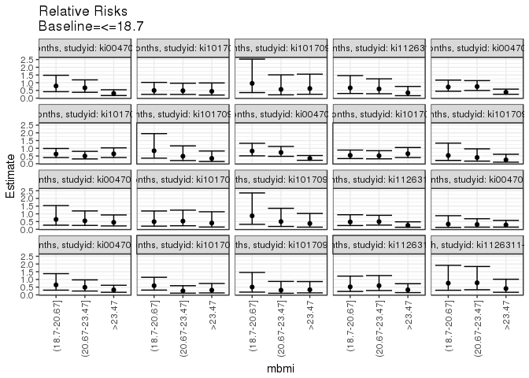

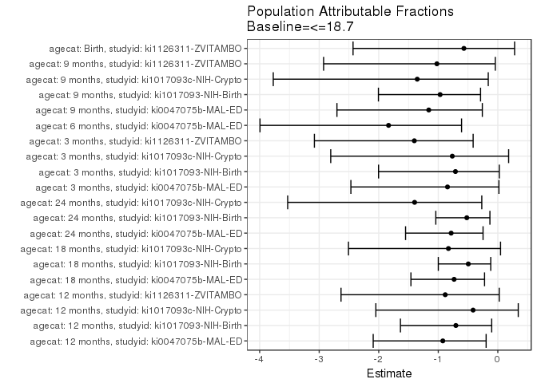

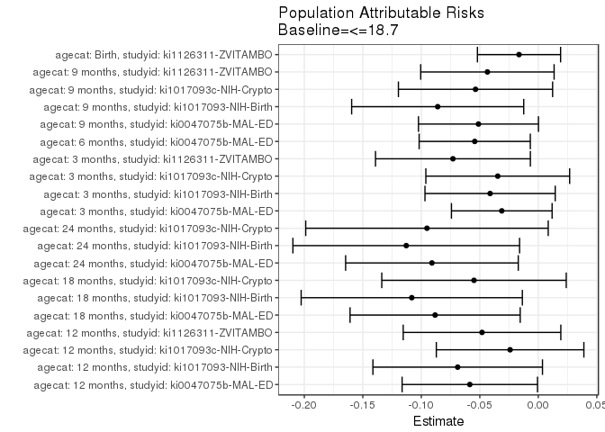

## Data Summary

| agecat | studyid | A | n | nA | nAY0 | nAY1 |
| --- | --- | --- | --- | --- | --- | --- |
| Birth | ki0047075b-MAL-ED | <=18.7 | 1425 | 105 | 101 | 4 |
| Birth | ki0047075b-MAL-ED | (18.7-20.67] | 1425 | 176 | 169 | 7 |
| Birth | ki0047075b-MAL-ED | (20.67-23.47] | 1425 | 381 | 370 | 11 |
| Birth | ki0047075b-MAL-ED | >23.47 | 1425 | 763 | 743 | 20 |
| Birth | ki1017093-NIH-Birth | <=18.7 | 28 | 10 | 10 | 0 |
| Birth | ki1017093-NIH-Birth | (18.7-20.67] | 28 | 9 | 9 | 0 |
| Birth | ki1017093-NIH-Birth | (20.67-23.47] | 28 | 6 | 6 | 0 |
| Birth | ki1017093-NIH-Birth | >23.47 | 28 | 3 | 3 | 0 |
| Birth | ki1017093b-PROVIDE | <=18.7 | 0 | 0 | 0 | 0 |
| Birth | ki1017093b-PROVIDE | (18.7-20.67] | 0 | 0 | 0 | 0 |
| Birth | ki1017093b-PROVIDE | (20.67-23.47] | 0 | 0 | 0 | 0 |
| Birth | ki1017093b-PROVIDE | >23.47 | 0 | 0 | 0 | 0 |
| Birth | ki1017093c-NIH-Crypto | <=18.7 | 27 | 7 | 7 | 0 |
| Birth | ki1017093c-NIH-Crypto | (18.7-20.67] | 27 | 5 | 5 | 0 |
| Birth | ki1017093c-NIH-Crypto | (20.67-23.47] | 27 | 8 | 7 | 1 |
| Birth | ki1017093c-NIH-Crypto | >23.47 | 27 | 7 | 7 | 0 |
| Birth | ki1066203-TanzaniaChild2 | <=18.7 | 0 | 0 | 0 | 0 |
| Birth | ki1066203-TanzaniaChild2 | (18.7-20.67] | 0 | 0 | 0 | 0 |
| Birth | ki1066203-TanzaniaChild2 | (20.67-23.47] | 0 | 0 | 0 | 0 |
| Birth | ki1066203-TanzaniaChild2 | >23.47 | 0 | 0 | 0 | 0 |
| Birth | ki1126311-ZVITAMBO | <=18.7 | 2383 | 132 | 126 | 6 |
| Birth | ki1126311-ZVITAMBO | (18.7-20.67] | 2383 | 436 | 421 | 15 |
| Birth | ki1126311-ZVITAMBO | (20.67-23.47] | 2383 | 846 | 816 | 30 |
| Birth | ki1126311-ZVITAMBO | >23.47 | 2383 | 969 | 951 | 18 |
| Birth | ki1148112-LCNI-5 | <=18.7 | 0 | 0 | 0 | 0 |
| Birth | ki1148112-LCNI-5 | (18.7-20.67] | 0 | 0 | 0 | 0 |
| Birth | ki1148112-LCNI-5 | (20.67-23.47] | 0 | 0 | 0 | 0 |
| Birth | ki1148112-LCNI-5 | >23.47 | 0 | 0 | 0 | 0 |
| 3 months | ki0047075b-MAL-ED | <=18.7 | 1759 | 132 | 123 | 9 |
| 3 months | ki0047075b-MAL-ED | (18.7-20.67] | 1759 | 229 | 219 | 10 |

[output cut: 166 more lines]

## Results Table

### Parameter: TSM

| agecat | studyid | intervention_level | baseline_level | estimate | ci_lower | ci_upper |
| --- | --- | --- | --- | --- | --- | --- |
| Birth | ki1126311-ZVITAMBO | <=18.7 | NA | 0.0454545 | 0.0099128 | 0.0809963 |
| Birth | ki1126311-ZVITAMBO | (18.7-20.67] | NA | 0.0344037 | 0.0172919 | 0.0515155 |
| Birth | ki1126311-ZVITAMBO | (20.67-23.47] | NA | 0.0354610 | 0.0229961 | 0.0479259 |
| Birth | ki1126311-ZVITAMBO | >23.47 | NA | 0.0185759 | 0.0100727 | 0.0270790 |
| 3 months | ki0047075b-MAL-ED | <=18.7 | NA | 0.0681818 | 0.0251703 | 0.1111933 |
| 3 months | ki0047075b-MAL-ED | (18.7-20.67] | NA | 0.0436681 | 0.0171929 | 0.0701434 |
| 3 months | ki0047075b-MAL-ED | (20.67-23.47] | NA | 0.0372671 | 0.0203699 | 0.0541642 |
| 3 months | ki0047075b-MAL-ED | >23.47 | NA | 0.0306011 | 0.0194381 | 0.0417641 |
| 3 months | ki1017093-NIH-Birth | <=18.7 | NA | 0.0990991 | 0.0434650 | 0.1547332 |
| 3 months | ki1017093-NIH-Birth | (18.7-20.67] | NA | 0.0487805 | 0.0157838 | 0.0817772 |
| 3 months | ki1017093-NIH-Birth | (20.67-23.47] | NA | 0.0526316 | 0.0191340 | 0.0861292 |
| 3 months | ki1017093-NIH-Birth | >23.47 | NA | 0.0403226 | 0.0056684 | 0.0749767 |
| 3 months | ki1017093c-NIH-Crypto | <=18.7 | NA | 0.0800000 | 0.0185595 | 0.1414405 |
| 3 months | ki1017093c-NIH-Crypto | (18.7-20.67] | NA | 0.0697674 | 0.0257754 | 0.1137595 |
| 3 months | ki1017093c-NIH-Crypto | (20.67-23.47] | NA | 0.0400000 | 0.0143775 | 0.0656225 |
| 3 months | ki1017093c-NIH-Crypto | >23.47 | NA | 0.0301003 | 0.0107201 | 0.0494806 |
| 3 months | ki1126311-ZVITAMBO | <=18.7 | NA | 0.1250000 | 0.0588264 | 0.1911736 |
| 3 months | ki1126311-ZVITAMBO | (18.7-20.67] | NA | 0.0597015 | 0.0343231 | 0.0850799 |
| 3 months | ki1126311-ZVITAMBO | (20.67-23.47] | NA | 0.0619597 | 0.0440187 | 0.0799007 |
| 3 months | ki1126311-ZVITAMBO | >23.47 | NA | 0.0313676 | 0.0192630 | 0.0434723 |
| 6 months | ki0047075b-MAL-ED | <=18.7 | NA | 0.0839695 | 0.0364626 | 0.1314764 |
| 6 months | ki0047075b-MAL-ED | (18.7-20.67] | NA | 0.0280374 | 0.0059134 | 0.0501614 |
| 6 months | ki0047075b-MAL-ED | (20.67-23.47] | NA | 0.0259179 | 0.0114407 | 0.0403951 |
| 6 months | ki0047075b-MAL-ED | >23.47 | NA | 0.0238636 | 0.0137767 | 0.0339506 |
| 9 months | ki0047075b-MAL-ED | <=18.7 | NA | 0.0952381 | 0.0439675 | 0.1465087 |
| 9 months | ki0047075b-MAL-ED | (18.7-20.67] | NA | 0.0616114 | 0.0291579 | 0.0940649 |
| 9 months | ki0047075b-MAL-ED | (20.67-23.47] | NA | 0.0467706 | 0.0272343 | 0.0663069 |
| 9 months | ki0047075b-MAL-ED | >23.47 | NA | 0.0306966 | 0.0190764 | 0.0423168 |
| 9 months | ki1017093-NIH-Birth | <=18.7 | NA | 0.1747573 | 0.1013453 | 0.2481692 |
| 9 months | ki1017093-NIH-Birth | (18.7-20.67] | NA | 0.1037037 | 0.0522244 | 0.1551830 |
| 9 months | ki1017093-NIH-Birth | (20.67-23.47] | NA | 0.0448718 | 0.0123532 | 0.0773904 |
| 9 months | ki1017093-NIH-Birth | >23.47 | NA | 0.0530973 | 0.0117139 | 0.0944808 |
| 9 months | ki1017093c-NIH-Crypto | <=18.7 | NA | 0.0933333 | 0.0274512 | 0.1592154 |
| 9 months | ki1017093c-NIH-Crypto | (18.7-20.67] | NA | 0.0472441 | 0.0103193 | 0.0841689 |
| 9 months | ki1017093c-NIH-Crypto | (20.67-23.47] | NA | 0.0281690 | 0.0059335 | 0.0504045 |
| 9 months | ki1017093c-NIH-Crypto | >23.47 | NA | 0.0309278 | 0.0110228 | 0.0508328 |
| 9 months | ki1126311-ZVITAMBO | <=18.7 | NA | 0.0860215 | 0.0290171 | 0.1430259 |
| 9 months | ki1126311-ZVITAMBO | (18.7-20.67] | NA | 0.0446735 | 0.0209307 | 0.0684164 |
| 9 months | ki1126311-ZVITAMBO | (20.67-23.47] | NA | 0.0510708 | 0.0335527 | 0.0685889 |
| 9 months | ki1126311-ZVITAMBO | >23.47 | NA | 0.0279823 | 0.0155737 | 0.0403909 |
| 12 months | ki0047075b-MAL-ED | <=18.7 | NA | 0.1219512 | 0.0641039 | 0.1797985 |
| 12 months | ki0047075b-MAL-ED | (18.7-20.67] | NA | 0.0961538 | 0.0560781 | 0.1362296 |
| 12 months | ki0047075b-MAL-ED | (20.67-23.47] | NA | 0.0818182 | 0.0562001 | 0.1074362 |
| 12 months | ki0047075b-MAL-ED | >23.47 | NA | 0.0369928 | 0.0242098 | 0.0497759 |
| 12 months | ki1017093-NIH-Birth | <=18.7 | NA | 0.1666667 | 0.0942690 | 0.2390643 |
| 12 months | ki1017093-NIH-Birth | (18.7-20.67] | NA | 0.0833333 | 0.0361358 | 0.1305308 |
| 12 months | ki1017093-NIH-Birth | (20.67-23.47] | NA | 0.0805369 | 0.0367986 | 0.1242753 |
| 12 months | ki1017093-NIH-Birth | >23.47 | NA | 0.0740741 | 0.0246316 | 0.1235165 |
| 12 months | ki1017093c-NIH-Crypto | <=18.7 | NA | 0.0821918 | 0.0191418 | 0.1452417 |
| 12 months | ki1017093c-NIH-Crypto | (18.7-20.67] | NA | 0.0787402 | 0.0318649 | 0.1256154 |
| 12 months | ki1017093c-NIH-Crypto | (20.67-23.47] | NA | 0.0467290 | 0.0184313 | 0.0750266 |
| 12 months | ki1017093c-NIH-Crypto | >23.47 | NA | 0.0513699 | 0.0260322 | 0.0767076 |
| 12 months | ki1126311-ZVITAMBO | <=18.7 | NA | 0.1025641 | 0.0352122 | 0.1699160 |
| 12 months | ki1126311-ZVITAMBO | (18.7-20.67] | NA | 0.0683453 | 0.0386726 | 0.0980180 |
| 12 months | ki1126311-ZVITAMBO | (20.67-23.47] | NA | 0.0612648 | 0.0403623 | 0.0821674 |
| 12 months | ki1126311-ZVITAMBO | >23.47 | NA | 0.0356537 | 0.0206738 | 0.0506335 |
| 18 months | ki0047075b-MAL-ED | <=18.7 | NA | 0.2083333 | 0.1356476 | 0.2810191 |
| 18 months | ki0047075b-MAL-ED | (18.7-20.67] | NA | 0.1507538 | 0.1010243 | 0.2004832 |
| 18 months | ki0047075b-MAL-ED | (20.67-23.47] | NA | 0.1567696 | 0.1220278 | 0.1915114 |
| 18 months | ki0047075b-MAL-ED | >23.47 | NA | 0.0800000 | 0.0611946 | 0.0988054 |
| 18 months | ki1017093-NIH-Birth | <=18.7 | NA | 0.3263158 | 0.2319308 | 0.4207008 |
| 18 months | ki1017093-NIH-Birth | (18.7-20.67] | NA | 0.2049180 | 0.1332156 | 0.2766204 |
| 18 months | ki1017093-NIH-Birth | (20.67-23.47] | NA | 0.1631206 | 0.1020694 | 0.2241717 |
| 18 months | ki1017093-NIH-Birth | >23.47 | NA | 0.2095238 | 0.1315975 | 0.2874501 |
| 18 months | ki1017093c-NIH-Crypto | <=18.7 | NA | 0.1212121 | 0.0424107 | 0.2000135 |
| 18 months | ki1017093c-NIH-Crypto | (18.7-20.67] | NA | 0.1016949 | 0.0471177 | 0.1562721 |
| 18 months | ki1017093c-NIH-Crypto | (20.67-23.47] | NA | 0.0588235 | 0.0250730 | 0.0925741 |
| 18 months | ki1017093c-NIH-Crypto | >23.47 | NA | 0.0418251 | 0.0176118 | 0.0660384 |
| 24 months | ki0047075b-MAL-ED | <=18.7 | NA | 0.2068966 | 0.1331559 | 0.2806372 |
| 24 months | ki0047075b-MAL-ED | (18.7-20.67] | NA | 0.1702128 | 0.1164731 | 0.2239524 |
| 24 months | ki0047075b-MAL-ED | (20.67-23.47] | NA | 0.1513648 | 0.1163610 | 0.1863685 |
| 24 months | ki0047075b-MAL-ED | >23.47 | NA | 0.0708763 | 0.0528149 | 0.0889377 |
| 24 months | ki1017093-NIH-Birth | <=18.7 | NA | 0.3296703 | 0.2329721 | 0.4263685 |
| 24 months | ki1017093-NIH-Birth | (18.7-20.67] | NA | 0.1794872 | 0.1098692 | 0.2491051 |
| 24 months | ki1017093-NIH-Birth | (20.67-23.47] | NA | 0.1707317 | 0.1041574 | 0.2373061 |
| 24 months | ki1017093-NIH-Birth | >23.47 | NA | 0.2142857 | 0.1329520 | 0.2956195 |
| 24 months | ki1017093c-NIH-Crypto | <=18.7 | NA | 0.1632653 | 0.0596763 | 0.2668543 |
| 24 months | ki1017093c-NIH-Crypto | (18.7-20.67] | NA | 0.0869565 | 0.0293232 | 0.1445899 |
| 24 months | ki1017093c-NIH-Crypto | (20.67-23.47] | NA | 0.0657895 | 0.0263392 | 0.1052397 |
| 24 months | ki1017093c-NIH-Crypto | >23.47 | NA | 0.0407240 | 0.0146401 | 0.0668078 |

### Parameter: E(Y)

| agecat | studyid | intervention_level | baseline_level | estimate | ci_lower | ci_upper |
| --- | --- | --- | --- | --- | --- | --- |
| Birth | ki1126311-ZVITAMBO | NA | NA | 0.0289551 | 0.0285974 | 0.0293128 |
| 3 months | ki0047075b-MAL-ED | NA | NA | 0.0369528 | 0.0364852 | 0.0374204 |
| 3 months | ki1017093-NIH-Birth | NA | NA | 0.0578947 | 0.0561909 | 0.0595986 |
| 3 months | ki1017093c-NIH-Crypto | NA | NA | 0.0453297 | 0.0440018 | 0.0466575 |
| 3 months | ki1126311-ZVITAMBO | NA | NA | 0.0520291 | 0.0510404 | 0.0530179 |
| 6 months | ki0047075b-MAL-ED | NA | NA | 0.0296209 | 0.0288655 | 0.0303762 |
| 9 months | ki0047075b-MAL-ED | NA | NA | 0.0440906 | 0.0432006 | 0.0449807 |
| 9 months | ki1017093-NIH-Birth | NA | NA | 0.0887574 | 0.0844552 | 0.0930596 |
| 9 months | ki1017093c-NIH-Crypto | NA | NA | 0.0396601 | 0.0382067 | 0.0411134 |
| 9 months | ki1126311-ZVITAMBO | NA | NA | 0.0425150 | 0.0418055 | 0.0432245 |
| 12 months | ki0047075b-MAL-ED | NA | NA | 0.0633934 | 0.0619628 | 0.0648240 |
| 12 months | ki1017093-NIH-Birth | NA | NA | 0.0977597 | 0.0946220 | 0.1008973 |
| 12 months | ki1017093c-NIH-Crypto | NA | NA | 0.0580737 | 0.0570440 | 0.0591033 |
| 12 months | ki1126311-ZVITAMBO | NA | NA | 0.0544452 | 0.0535230 | 0.0553675 |
| 18 months | ki0047075b-MAL-ED | NA | NA | 0.1201299 | 0.1179344 | 0.1223253 |
| 18 months | ki1017093-NIH-Birth | NA | NA | 0.2181425 | 0.2128366 | 0.2234485 |
| 18 months | ki1017093c-NIH-Crypto | NA | NA | 0.0662461 | 0.0640261 | 0.0684660 |
| 24 months | ki0047075b-MAL-ED | NA | NA | 0.1159811 | 0.1134744 | 0.1184878 |
| 24 months | ki1017093-NIH-Birth | NA | NA | 0.2167832 | 0.2110267 | 0.2225397 |
| 24 months | ki1017093c-NIH-Crypto | NA | NA | 0.0680934 | 0.0650329 | 0.0711538 |

### Parameter: RR

| agecat | studyid | intervention_level | baseline_level | estimate | ci_lower | ci_upper |
| --- | --- | --- | --- | --- | --- | --- |
| Birth | ki1126311-ZVITAMBO | (18.7-20.67] | <=18.7 | 0.7568807 | 0.2996147 | 1.9120169 |
| Birth | ki1126311-ZVITAMBO | (20.67-23.47] | <=18.7 | 0.7801418 | 0.3310201 | 1.8386233 |
| Birth | ki1126311-ZVITAMBO | >23.47 | <=18.7 | 0.4086687 | 0.1651493 | 1.0112676 |
| 3 months | ki0047075b-MAL-ED | (18.7-20.67] | <=18.7 | 0.6404658 | 0.2669999 | 1.5363168 |
| 3 months | ki0047075b-MAL-ED | (20.67-23.47] | <=18.7 | 0.5465839 | 0.2513422 | 1.1886343 |
| 3 months | ki0047075b-MAL-ED | >23.47 | <=18.7 | 0.4488160 | 0.2165666 | 0.9301333 |
| 3 months | ki1017093-NIH-Birth | (18.7-20.67] | <=18.7 | 0.4922395 | 0.2043664 | 1.1856141 |
| 3 months | ki1017093-NIH-Birth | (20.67-23.47] | <=18.7 | 0.5311005 | 0.2273020 | 1.2409380 |
| 3 months | ki1017093-NIH-Birth | >23.47 | <=18.7 | 0.4068915 | 0.1457671 | 1.1357891 |
| 3 months | ki1017093c-NIH-Crypto | (18.7-20.67] | <=18.7 | 0.8720930 | 0.3228542 | 2.3556954 |
| 3 months | ki1017093c-NIH-Crypto | (20.67-23.47] | <=18.7 | 0.5000000 | 0.1839256 | 1.3592450 |
| 3 months | ki1017093c-NIH-Crypto | >23.47 | <=18.7 | 0.3762542 | 0.1381134 | 1.0250070 |
| 3 months | ki1126311-ZVITAMBO | (18.7-20.67] | <=18.7 | 0.4776119 | 0.2422243 | 0.9417436 |
| 3 months | ki1126311-ZVITAMBO | (20.67-23.47] | <=18.7 | 0.4956772 | 0.2711089 | 0.9062628 |
| 3 months | ki1126311-ZVITAMBO | >23.47 | <=18.7 | 0.2509410 | 0.1303351 | 0.4831500 |
| 6 months | ki0047075b-MAL-ED | (18.7-20.67] | <=18.7 | 0.3338997 | 0.1264551 | 0.8816491 |
| 6 months | ki0047075b-MAL-ED | (20.67-23.47] | <=18.7 | 0.3086589 | 0.1393781 | 0.6835386 |
| 6 months | ki0047075b-MAL-ED | >23.47 | <=18.7 | 0.2841942 | 0.1402506 | 0.5758715 |
| 9 months | ki0047075b-MAL-ED | (18.7-20.67] | <=18.7 | 0.6469194 | 0.3046145 | 1.3738831 |
| 9 months | ki0047075b-MAL-ED | (20.67-23.47] | <=18.7 | 0.4910913 | 0.2484502 | 0.9707003 |
| 9 months | ki0047075b-MAL-ED | >23.47 | <=18.7 | 0.3223140 | 0.1669032 | 0.6224348 |
| 9 months | ki1017093-NIH-Birth | (18.7-20.67] | <=18.7 | 0.5934156 | 0.3096978 | 1.1370506 |
| 9 months | ki1017093-NIH-Birth | (20.67-23.47] | <=18.7 | 0.2567664 | 0.1111095 | 0.5933692 |
| 9 months | ki1017093-NIH-Birth | >23.47 | <=18.7 | 0.3038348 | 0.1253482 | 0.7364731 |
| 9 months | ki1017093c-NIH-Crypto | (18.7-20.67] | <=18.7 | 0.5061867 | 0.1765766 | 1.4510700 |
| 9 months | ki1017093c-NIH-Crypto | (20.67-23.47] | <=18.7 | 0.3018109 | 0.1046749 | 0.8702164 |
| 9 months | ki1017093c-NIH-Crypto | >23.47 | <=18.7 | 0.3313697 | 0.1274847 | 0.8613260 |
| 9 months | ki1126311-ZVITAMBO | (18.7-20.67] | <=18.7 | 0.5193299 | 0.2220864 | 1.2144084 |
| 9 months | ki1126311-ZVITAMBO | (20.67-23.47] | <=18.7 | 0.5936985 | 0.2815139 | 1.2520800 |
| 9 months | ki1126311-ZVITAMBO | >23.47 | <=18.7 | 0.3252946 | 0.1465508 | 0.7220470 |
| 12 months | ki0047075b-MAL-ED | (18.7-20.67] | <=18.7 | 0.7884615 | 0.4193234 | 1.4825590 |
| 12 months | ki0047075b-MAL-ED | (20.67-23.47] | <=18.7 | 0.6709091 | 0.3800355 | 1.1844130 |
| 12 months | ki0047075b-MAL-ED | >23.47 | <=18.7 | 0.3033413 | 0.1686778 | 0.5455129 |
| 12 months | ki1017093-NIH-Birth | (18.7-20.67] | <=18.7 | 0.5000000 | 0.2448974 | 1.0208358 |
| 12 months | ki1017093-NIH-Birth | (20.67-23.47] | <=18.7 | 0.4832215 | 0.2410583 | 0.9686579 |
| 12 months | ki1017093-NIH-Birth | >23.47 | <=18.7 | 0.4444444 | 0.2004272 | 0.9855493 |
| 12 months | ki1017093c-NIH-Crypto | (18.7-20.67] | <=18.7 | 0.9580052 | 0.3627981 | 2.5297101 |
| 12 months | ki1017093c-NIH-Crypto | (20.67-23.47] | <=18.7 | 0.5685358 | 0.2139489 | 1.5107954 |
| 12 months | ki1017093c-NIH-Crypto | >23.47 | <=18.7 | 0.6250000 | 0.2510755 | 1.5558068 |
| 12 months | ki1126311-ZVITAMBO | (18.7-20.67] | <=18.7 | 0.6663669 | 0.3032674 | 1.4642022 |
| 12 months | ki1126311-ZVITAMBO | (20.67-23.47] | <=18.7 | 0.5973320 | 0.2849884 | 1.2520003 |
| 12 months | ki1126311-ZVITAMBO | >23.47 | <=18.7 | 0.3476231 | 0.1594183 | 0.7580172 |
| 18 months | ki0047075b-MAL-ED | (18.7-20.67] | <=18.7 | 0.7236181 | 0.4476972 | 1.1695921 |
| 18 months | ki0047075b-MAL-ED | (20.67-23.47] | <=18.7 | 0.7524941 | 0.4977358 | 1.1376463 |
| 18 months | ki0047075b-MAL-ED | >23.47 | <=18.7 | 0.3840000 | 0.2521313 | 0.5848380 |
| 18 months | ki1017093-NIH-Birth | (18.7-20.67] | <=18.7 | 0.6279746 | 0.3988239 | 0.9887877 |
| 18 months | ki1017093-NIH-Birth | (20.67-23.47] | <=18.7 | 0.4998856 | 0.3114900 | 0.8022268 |
| 18 months | ki1017093-NIH-Birth | >23.47 | <=18.7 | 0.6420891 | 0.4008437 | 1.0285266 |
| 18 months | ki1017093c-NIH-Crypto | (18.7-20.67] | <=18.7 | 0.8389831 | 0.3611092 | 1.9492514 |
| 18 months | ki1017093c-NIH-Crypto | (20.67-23.47] | <=18.7 | 0.4852941 | 0.2039072 | 1.1549880 |
| 18 months | ki1017093c-NIH-Crypto | >23.47 | <=18.7 | 0.3450571 | 0.1444882 | 0.8240421 |
| 24 months | ki0047075b-MAL-ED | (18.7-20.67] | <=18.7 | 0.8226950 | 0.5110385 | 1.3244151 |
| 24 months | ki0047075b-MAL-ED | (20.67-23.47] | <=18.7 | 0.7315964 | 0.4783609 | 1.1188901 |
| 24 months | ki0047075b-MAL-ED | >23.47 | <=18.7 | 0.3425687 | 0.2210370 | 0.5309217 |
| 24 months | ki1017093-NIH-Birth | (18.7-20.67] | <=18.7 | 0.5444444 | 0.3347802 | 0.8854161 |
| 24 months | ki1017093-NIH-Birth | (20.67-23.47] | <=18.7 | 0.5178862 | 0.3179251 | 0.8436140 |
| 24 months | ki1017093-NIH-Birth | >23.47 | <=18.7 | 0.6500000 | 0.4023353 | 1.0501192 |
| 24 months | ki1017093c-NIH-Crypto | (18.7-20.67] | <=18.7 | 0.5326087 | 0.2127809 | 1.3331650 |
| 24 months | ki1017093c-NIH-Crypto | (20.67-23.47] | <=18.7 | 0.4029605 | 0.1683141 | 0.9647274 |
| 24 months | ki1017093c-NIH-Crypto | >23.47 | <=18.7 | 0.2494344 | 0.1012542 | 0.6144684 |

### Parameter: PAR

| agecat | studyid | intervention_level | baseline_level | estimate | ci_lower | ci_upper |
| --- | --- | --- | --- | --- | --- | --- |
| Birth | ki1126311-ZVITAMBO | <=18.7 | NA | -0.0164994 | -0.0520430 | 0.0190441 |
| 3 months | ki0047075b-MAL-ED | <=18.7 | NA | -0.0312290 | -0.0742430 | 0.0117850 |
| 3 months | ki1017093-NIH-Birth | <=18.7 | NA | -0.0412044 | -0.0968646 | 0.0144558 |
| 3 months | ki1017093c-NIH-Crypto | <=18.7 | NA | -0.0346703 | -0.0961252 | 0.0267845 |
| 3 months | ki1126311-ZVITAMBO | <=18.7 | NA | -0.0729709 | -0.1391518 | -0.0067899 |
| 6 months | ki0047075b-MAL-ED | <=18.7 | NA | -0.0543486 | -0.1018615 | -0.0068357 |
| 9 months | ki0047075b-MAL-ED | <=18.7 | NA | -0.0511475 | -0.1024258 | 0.0001309 |
| 9 months | ki1017093-NIH-Birth | <=18.7 | NA | -0.0859999 | -0.1595378 | -0.0124620 |
| 9 months | ki1017093c-NIH-Crypto | <=18.7 | NA | -0.0536733 | -0.1195714 | 0.0122249 |
| 9 months | ki1126311-ZVITAMBO | <=18.7 | NA | -0.0435065 | -0.1005153 | 0.0135023 |
| 12 months | ki0047075b-MAL-ED | <=18.7 | NA | -0.0585578 | -0.1164228 | -0.0006928 |
| 12 months | ki1017093-NIH-Birth | <=18.7 | NA | -0.0689070 | -0.1413726 | 0.0035586 |
| 12 months | ki1017093c-NIH-Crypto | <=18.7 | NA | -0.0241181 | -0.0871765 | 0.0389402 |
| 12 months | ki1126311-ZVITAMBO | <=18.7 | NA | -0.0481189 | -0.1154771 | 0.0192393 |
| 18 months | ki0047075b-MAL-ED | <=18.7 | NA | -0.0882035 | -0.1609223 | -0.0154846 |
| 18 months | ki1017093-NIH-Birth | <=18.7 | NA | -0.1081732 | -0.2027073 | -0.0136392 |
| 18 months | ki1017093c-NIH-Crypto | <=18.7 | NA | -0.0549661 | -0.1337987 | 0.0238666 |
| 24 months | ki0047075b-MAL-ED | <=18.7 | NA | -0.0909154 | -0.1646987 | -0.0171322 |
| 24 months | ki1017093-NIH-Birth | <=18.7 | NA | -0.1128871 | -0.2097565 | -0.0160177 |
| 24 months | ki1017093c-NIH-Crypto | <=18.7 | NA | -0.0951719 | -0.1988061 | 0.0084623 |

### Parameter: PAF

| agecat | studyid | intervention_level | baseline_level | estimate | ci_lower | ci_upper |
| --- | --- | --- | --- | --- | --- | --- |
| Birth | ki1126311-ZVITAMBO | <=18.7 | NA | -0.5698287 | -2.4314516 | 0.2818310 |
| 3 months | ki0047075b-MAL-ED | <=18.7 | NA | -0.8451049 | -2.4677232 | 0.0182572 |
| 3 months | ki1017093-NIH-Birth | <=18.7 | NA | -0.7117117 | -2.0031556 | 0.0243740 |
| 3 months | ki1017093c-NIH-Crypto | <=18.7 | NA | -0.7648485 | -2.8061940 | 0.1816786 |
| 3 months | ki1126311-ZVITAMBO | <=18.7 | NA | -1.4025000 | -3.0805808 | -0.4145061 |
| 6 months | ki0047075b-MAL-ED | <=18.7 | NA | -1.8348092 | -3.9943796 | -0.6090373 |
| 9 months | ki0047075b-MAL-ED | <=18.7 | NA | -1.1600529 | -2.7019225 | -0.2603799 |
| 9 months | ki1017093-NIH-Birth | <=18.7 | NA | -0.9689320 | -2.0052416 | -0.2899773 |
| 9 months | ki1017093c-NIH-Crypto | <=18.7 | NA | -1.3533333 | -3.7715110 | -0.1606759 |
| 9 months | ki1126311-ZVITAMBO | <=18.7 | NA | -1.0233227 | -2.9260233 | -0.0427434 |
| 12 months | ki0047075b-MAL-ED | <=18.7 | NA | -0.9237207 | -2.0930120 | -0.1964717 |
| 12 months | ki1017093-NIH-Birth | <=18.7 | NA | -0.7048611 | -1.6354492 | -0.1028676 |
| 12 months | ki1017093c-NIH-Crypto | <=18.7 | NA | -0.4153024 | -2.0485180 | 0.3429329 |
| 12 months | ki1126311-ZVITAMBO | <=18.7 | NA | -0.8838040 | -2.6334865 | 0.0233300 |
| 18 months | ki0047075b-MAL-ED | <=18.7 | NA | -0.7342342 | -1.4594450 | -0.2228647 |
| 18 months | ki1017093-NIH-Birth | <=18.7 | NA | -0.4958833 | -0.9996699 | -0.1190181 |
| 18 months | ki1017093c-NIH-Crypto | <=18.7 | NA | -0.8297258 | -2.5083322 | 0.0457299 |
| 24 months | ki0047075b-MAL-ED | <=18.7 | NA | -0.7838813 | -1.5494037 | -0.2482262 |
| 24 months | ki1017093-NIH-Birth | <=18.7 | NA | -0.5207373 | -1.0415568 | -0.1327836 |
| 24 months | ki1017093c-NIH-Crypto | <=18.7 | NA | -1.3976676 | -3.5293078 | -0.2692469 |